# Recommendation systems (Part 2)

Stefano Galelli

Term 6, 2020

First, we prepare the working environment.

```r
rm(list=ls()) # Clear the environment
setwd("~/Documents/SUTD/Term 6/TAE/W11")
# setwd("...")  # Setup the working directory
```

# 1 `ratings` dataset

The data come from [grouples](https://grouplens.org), a research lab in the Department of Computer Science and Engineering at the University of Minnesota. We begin by loading the data.

```r
ratings <- read.csv("ratings.csv")
str(ratings)
```

```
## 'data.frame':    100023 obs. of  3 variables:
##  $ userId : int  1 1 1 1 1 1 1 1 1 1 ...
##  $ movieId: int  6 22 32 50 110 164 198 260 296 303 ...
##  $ rating : num  2 3 2 5 4 3 3 5 4 3 ...
```

A quick look at the dataframe:

```r
length(unique(ratings$userId))  # number of rows for the matrix to be created
```

```
## [1] 706
```

```r
length(unique(ratings$movieId))  # number of columns
```

```
## [1] 8552
```

```r
sort(unique(ratings$rating))
```

```
##  [1] 0.5 1.0 1.5 2.0 2.5 3.0 3.5 4.0 4.5 5.0
```

The `ratings` dataframe consists of 100,023 observations of 3 variables (userId, movieId, and rating). We have 706 users, 8552 movies, and 100,023 ratings. Ratings go from 0.5 to 5.0, with 0.5 increments.

Let’s now look at the user behavior:

```r
max(table(ratings$userId)) # max number of ratings by a user
```

```
## [1] 2268
```

```r
min(table(ratings$userId))
```

```
## [1] 20
```

Users have rated from 20 to 2268 movies. Who has been watching them?

```r
which(table(ratings$userId) == 2268)
```

```
## 516
## 516
```

```r
which(table(ratings$userId) == 20)
```

```
##  16  17  81 122 135 461 482 496 505 533 535 573 607 653 684
##  16  17  81 122 135 461 482 496 505 533 535 573 607 653 684
```

Movies have from 1 to 337 ratings

```r
max(table(ratings$movieId))
```

```
## [1] 337
```

```r
min(table(ratings$movieId))
```

```
## [1] 1
```

# 2 Data preparation

Create an empty matrix with 706 rows (users) and 8552 (movies). We name the rows and columns with the unique users and movieid in the dataset.

```r
Data <- matrix(nrow = length(unique(ratings$userId)), ncol = length(unique(ratings$movieId)))
rownames(Data) <- unique(ratings$userId)
colnames(Data) <- unique(ratings$movieId)
```

Now, let’s fill in the matrix:

```r
for(i in 1:nrow(ratings))
{Data[as.character(ratings$userId[i]), as.character(ratings$movieId[i])] <- ratings$rating[i]}

dim(Data)
```

```
## [1]  706 8552
```

Visual check: how are the rating distributed?

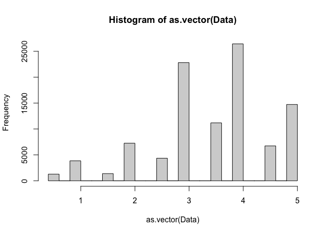

```r
hist(as.vector(Data))
```

Normalize the ratings of each user so that bias is reduced (`na.rm=TRUE` to omit the missing values).

```r
Datanorm <- Data - rowMeans(Data, na.rm = TRUE)
```

The histogram below shows that we now have a more symmetric rating.

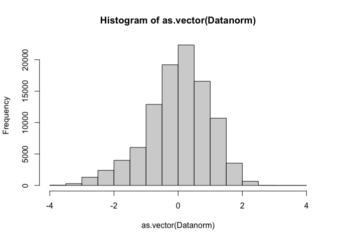

```r
hist(as.vector(Datanorm))
```

Finally, we create a matrix with `spl1` + `spl1c` rows and `spl2` + `spl2c` columns

```r
set.seed(1)
spl1 <- sample(1:nrow(Data), 0.98 * nrow(Data)) # spl1 has 98% of the rows
spl1c <- setdiff(1:nrow(Data), spl1)           # spl1c has the remaining ones

set.seed(2)
spl2 <- sample(1:ncol(Data), 0.8 * ncol(Data))  # spl2 has 80% of the columns
spl2c <- setdiff(1:ncol(Data), spl2)           # spl2c has the rest
```

Check the dimensions

```r
length(spl1)  # 691 users
```

```
## [1] 691
```

```r
length(spl1c)
```

```
## [1] 15
```

```r
length(spl2)  # 6841 movies
```

```
## [1] 6841
```

```r
length(spl2c)
```

```
## [1] 1711
```

# 3 Models

We are going to create three different prediction models. But, first, we initialize the matrices that will contain the model predictions.

```r
# ie. initialise the testing matrix (empty)
Base1    <- matrix(nrow = length(spl1c), ncol = length(spl2c))
Base2    <- matrix(nrow = length(spl1c), ncol = length(spl2c))
UserPred <- matrix(nrow = length(spl1c), ncol = length(spl2c))
```

## 3.1 Baseline model 1

Average out the item rating for all users in the training set `spl1`:

```r
for(i in 1:length(spl1c))
{Base1[i,] <- colMeans(Data[spl1, spl2c], na.rm = TRUE)}
```

Note that all rows (users) contain the same information. E.g.:

```r
Base1[,1:10]
```

```
##           [,1]     [,2]     [,3]     [,4]     [,5] [,6]     [,7]     [,8]
##  [1,] 4.371308 3.113514 3.678947 3.395197 3.457806 3.46 3.796296 2.958333
##  [2,] 4.371308 3.113514 3.678947 3.395197 3.457806 3.46 3.796296 2.958333
##  [3,] 4.371308 3.113514 3.678947 3.395197 3.457806 3.46 3.796296 2.958333
##  [4,] 4.371308 3.113514 3.678947 3.395197 3.457806 3.46 3.796296 2.958333
##  [5,] 4.371308 3.113514 3.678947 3.395197 3.457806 3.46 3.796296 2.958333
##  [6,] 4.371308 3.113514 3.678947 3.395197 3.457806 3.46 3.796296 2.958333
##  [7,] 4.371308 3.113514 3.678947 3.395197 3.457806 3.46 3.796296 2.958333
##  [8,] 4.371308 3.113514 3.678947 3.395197 3.457806 3.46 3.796296 2.958333
##  [9,] 4.371308 3.113514 3.678947 3.395197 3.457806 3.46 3.796296 2.958333
## [10,] 4.371308 3.113514 3.678947 3.395197 3.457806 3.46 3.796296 2.958333
## [11,] 4.371308 3.113514 3.678947 3.395197 3.457806 3.46 3.796296 2.958333
## [12,] 4.371308 3.113514 3.678947 3.395197 3.457806 3.46 3.796296 2.958333
## [13,] 4.371308 3.113514 3.678947 3.395197 3.457806 3.46 3.796296 2.958333
## [14,] 4.371308 3.113514 3.678947 3.395197 3.457806 3.46 3.796296 2.958333
```

[output cut: 17 more lines]

## 3.2 Baseline model 2

Average over the user rating for all the items in the training set `spl2`:

```r
for(j in 1:length(spl2c))
{Base2[,j] <- rowMeans(Data[spl1c,spl2], na.rm = TRUE)}
```

All columns (movies) contain the same information. E.g.:

```r
Base2[,1:10]
```

```
##           [,1]     [,2]     [,3]     [,4]     [,5]     [,6]     [,7]     [,8]
##  [1,] 3.796875 3.796875 3.796875 3.796875 3.796875 3.796875 3.796875 3.796875
##  [2,] 3.775510 3.775510 3.775510 3.775510 3.775510 3.775510 3.775510 3.775510
##  [3,] 3.937500 3.937500 3.937500 3.937500 3.937500 3.937500 3.937500 3.937500
##  [4,] 3.571429 3.571429 3.571429 3.571429 3.571429 3.571429 3.571429 3.571429
##  [5,] 3.000000 3.000000 3.000000 3.000000 3.000000 3.000000 3.000000 3.000000
##  [6,] 3.651515 3.651515 3.651515 3.651515 3.651515 3.651515 3.651515 3.651515
##  [7,] 3.590909 3.590909 3.590909 3.590909 3.590909 3.590909 3.590909 3.590909
##  [8,] 3.773585 3.773585 3.773585 3.773585 3.773585 3.773585 3.773585 3.773585
##  [9,] 3.700000 3.700000 3.700000 3.700000 3.700000 3.700000 3.700000 3.700000
## [10,] 3.655172 3.655172 3.655172 3.655172 3.655172 3.655172 3.655172 3.655172
## [11,] 3.880952 3.880952 3.880952 3.880952 3.880952 3.880952 3.880952 3.880952
## [12,] 4.000000 4.000000 4.000000 4.000000 4.000000 4.000000 4.000000 4.000000
## [13,] 2.879828 2.879828 2.879828 2.879828 2.879828 2.879828 2.879828 2.879828
## [14,] 3.398305 3.398305 3.398305 3.398305 3.398305 3.398305 3.398305 3.398305
```

[output cut: 17 more lines]

## 3.3 User-based model

### 3.3.1 Calculate the correlation between users

Initialize matrices:

```r
Cor   <- matrix(nrow = length(spl1), ncol = 1) # keeps track of the correlation between users
Order <- matrix(nrow = length(spl1c), ncol = length(spl1)) # sort users in terms of decreasing correlations
```

With this command, we create an `Order` matrix of dimensions 15x691, where each row corresponds to neighbors of the users in the `spl1c` in decreasing order of Pearson correlation. The `NA` accounts for users who have no common ratings of movies with the user.

```r
for(i in 1:length(spl1c)) {
  for(j in 1:length(spl1)) {
      Cor[j] <- cor(Data[spl1c[i], spl2], Data[spl1[j], spl2], use = "pairwise.complete.obs")
      }
  V <- order(Cor, decreasing = TRUE, na.last = NA)
  Order[i,] <- c(V, rep(NA, times = length(spl1) - length(V)))
}
```

Let’s check the results

```r
length(Cor)
```

```
## [1] 691
```

```r
dim(Order)
```

```
## [1]  15 691
```

```r
# Order[,1:20]
# Order[,500:520]
# Order[,671:691]
```

### 3.3.2 Predictions

Now, we compute user predictions by looking at the 250 nearest neighbours and averaging equally over all these user ratings in the items in `spl2c`:

```r
for(i in 1:length(spl1c))
{UserPred[i,] <- colMeans(Data[spl1[Order[i,1:250]], spl2c], na.rm = TRUE)}
```

Check:

```r
UserPred[,1:10]
```

```
##           [,1]     [,2]     [,3]     [,4]     [,5]     [,6]     [,7]     [,8]
##  [1,] 4.387500 3.005376 3.696078 3.470000 3.286290 3.406250 3.858586 2.666667
##  [2,] 4.438095 2.923529 3.675000 3.363636 3.259259 3.208333 3.722222 2.750000
##  [3,] 4.352381 3.107955 3.710000 3.391892 3.385870 2.666667 3.729167 2.916667
##  [4,] 4.340000 3.026596 3.680556 3.424419 3.300885 3.214286 3.799020 2.937500
##  [5,] 4.352459 3.019608 3.705882 3.412214 3.327731 3.208333 3.697674 3.071429
##  [6,] 4.353175 3.065000 3.663934 3.384956 3.398601 3.431818 3.703297 2.954545
##  [7,] 4.429134 3.060606 3.648936 3.406977 3.391304 3.409091 3.820225 3.333333
##  [8,] 4.424242 3.074766 3.673077 3.452586 3.308000 3.250000 3.797030 2.750000
##  [9,] 4.368217 3.100000 3.721429 3.386364 3.405882 3.404762 3.805263 2.857143
## [10,] 4.410714 3.018519 3.675000 3.423810 3.166667 3.291667 3.676056 3.000000
## [11,] 4.395652 3.059140 3.642857 3.359551 3.232456 3.227273 3.806604 3.000000
## [12,] 4.361538 3.055046 3.712963 3.415254 3.434783 3.350000 3.815000 2.888889
## [13,] 4.362637 3.246914 3.674419 3.281609 3.432584 3.388889 3.898305 3.333333
## [14,] 4.396694 2.946237 3.719512 3.448454 3.287037 3.321429 3.773684 2.944444
```

[output cut: 17 more lines]

## 3.4 Compare the model performance

Calculate the model error:

```r
RMSEBase1    <- sqrt(mean((Data[spl1c,spl2c] - Base1)^2, na.rm = TRUE))
RMSEBase2    <- sqrt(mean((Data[spl1c,spl2c] - Base2)^2, na.rm = TRUE))
RMSEUserPred <- sqrt(mean((Data[spl1c,spl2c] - UserPred)^2, na.rm = TRUE))

RMSEBase1
```

```
## [1] 0.9832191
```

```r
RMSEBase2
```

```
## [1] 1.036838
```

```r
RMSEUserPred
```

```
## [1] 0.9893346
```

Last step: we vary the neighborhood set for the third model to see whether it positively affects the results

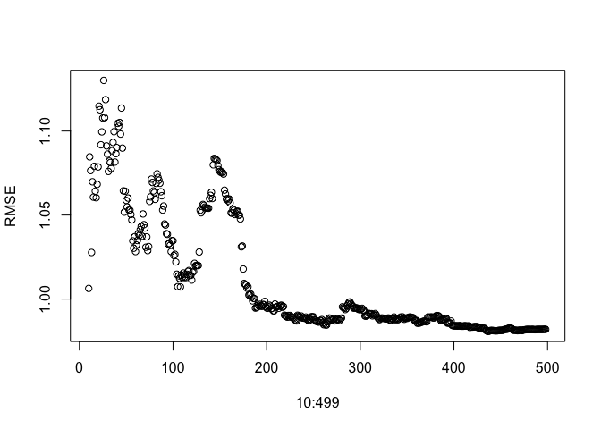

```r
RMSE <- rep(NA, times = 490)
for(k in 10:499)
{for(i in 1:length(spl1c))
{UserPred[i,] <- colMeans(Data[spl1[Order[i,1:k]], spl2c], na.rm = TRUE)}
  RMSE[k-10] <- sqrt(mean((Data[spl1c,spl2c] - UserPred)^2, na.rm = TRUE))}

plot(10:499,RMSE)
```

```r
# based on the plot, models with small neighbourhood tend to give unstable model performance
```

```r
min(RMSE, na.rm = TRUE)
```

```
## [1] 0.9807222
```